## BERCHES, CHARLES ANDREI V. BSIT-3A

```python
import pandas as pd
import numpy as np
import calendar
import seaborn as sns
import matplotlib.pyplot as plt
import folium
from folium.plugins import HeatMap
import warnings
warnings.filterwarnings('ignore')
```

# CHICAGO'S CRIME

```python
crimes = pd.read_csv('datasets//Chicago_Crimes.csv')
crimes
```

|  | ID | Case Number | Date | Block | IUCR | Primary Type | Description | Location Description | Arrest | Domestic | ... | Ward | Community Area | FBI Code | X Coordinate | Y Coordinate | Year | Updated On | Latitude | Longitude | Location |
| --- | --- | --- | --- | --- | --- | --- | --- | --- | --- | --- | --- | --- | --- | --- | --- | --- | --- | --- | --- | --- | --- |
| 0 | 13439321 | JH237424 | 04/14/2024 12:00:00 AM | 040XX S PRAIRIE AVE | 0890 | THEFT | FROM BUILDING | APARTMENT | False | False | ... | 3 | 38.0 | 06 | 1178707.0 | 1878256.0 | 2024 | 12/21/2024 03:40:46 PM | 41.821236 | -87.619921 | (41.821236024, -87.619920712) |
| 1 | 13437420 | JH234779 | 04/14/2024 12:00:00 AM | 023XX W CERMAK RD | 2825 | OTHER OFFENSE | HARASSMENT BY TELEPHONE | COMMERCIAL / BUSINESS OFFICE | False | False | ... | 25 | 31.0 | 26 | 1161210.0 | 1889347.0 | 2024 | 12/21/2024 03:40:46 PM | 41.852052 | -87.683801 | (41.852051675, -87.683800849) |
| 2 | 13428676 | JH224478 | 04/14/2024 12:00:00 AM | 043XX W LE MOYNE ST | 0917 | MOTOR VEHICLE THEFT | CYCLE, SCOOTER, BIKE WITH VIN | STREET | False | False | ... | 36 | 23.0 | 07 | 1146960.0 | 1909501.0 | 2024 | 12/21/2024 03:40:46 PM | 41.907640 | -87.735587 | (41.907640473, -87.735587478) |
| 3 | 13429357 | JH225293 | 04/14/2024 12:00:00 AM | 039XX W ADAMS ST | 143A | WEAPONS VIOLATION | UNLAWFUL POSSESSION - HANDGUN | STREET | True | False | ... | 28 | 26.0 | 15 | 1150158.0 | 1898721.0 | 2024 | 12/21/2024 03:40:46 PM | 41.877997 | -87.724121 | (41.877997275, -87.724120826) |
| 4 | 13430098 | JH226395 | 04/14/2024 12:00:00 AM | 011XX W 112TH PL | 0890 | THEFT | FROM BUILDING | RESIDENCE | False | False | ... | 21 | 75.0 | 06 | 1170856.0 | 1830157.0 | 2024 | 12/21/2024 03:40:46 PM | 41.689421 | -87.650123 | (41.6894214, -87.650123247) |
| ... | ... | ... | ... | ... | ... | ... | ... | ... | ... | ... | ... | ... | ... | ... | ... | ... | ... | ... | ... | ... | ... |
| 249118 | 13805239 | JJ217509 | 04/12/2025 12:00:00 AM | 029XX W LOGAN BLVD | 2826 | OTHER OFFENSE | HARASSMENT BY ELECTRONIC MEANS | APARTMENT | False | False | ... | 1 | 22.0 | 26 | 1156478.0 | 1917149.0 | 2025 | 04/19/2025 03:41:24 PM | 41.928440 | -87.700416 | (41.928439867, -87.700415972) |
| 249119 | 13804023 | JJ215813 | 04/12/2025 12:00:00 AM | 094XX S HARVARD AVE | 0430 | BATTERY | AGGRAVATED - OTHER DANGEROUS WEAPON | STREET | False | False | ... | 9 | 49.0 | 04B | 1175694.0 | 1842631.0 | 2025 | 04/19/2025 03:41:24 PM | 41.723545 | -87.632040 | (41.723545182, -87.632039508) |
| 249120 | 13803926 | JJ215943 | 04/12/2025 12:00:00 AM | 084XX S VINCENNES AVE | 0486 | BATTERY | DOMESTIC BATTERY SIMPLE | APARTMENT | False | True | ... | 21 | 71.0 | 08B | 1173850.0 | 1848976.0 | 2025 | 04/19/2025 03:41:24 PM | 41.740998 | -87.638606 | (41.74099774, -87.638606337) |
| 249121 | 13803475 | JJ215338 | 04/12/2025 12:00:00 AM | 050XX S ABERDEEN ST | 0530 | ASSAULT | AGGRAVATED - OTHER DANGEROUS WEAPON | STREET | True | False | ... | 20 | 61.0 | 04A | 1169838.0 | 1871348.0 | 2025 | 04/19/2025 03:41:24 PM | 41.802477 | -87.652657 | (41.802477219, -87.652657244) |
| 249122 | 13804512 | JJ216668 | 04/12/2025 12:00:00 AM | 012XX W CARROLL AVE | 0710 | THEFT | THEFT FROM MOTOR VEHICLE | STREET | False | False | ... | 27 | 28.0 | 06 | 1168216.0 | 1902390.0 | 2025 | 04/19/2025 03:41:24 PM | 41.887694 | -87.657710 | (41.887694407, -87.657710204) |

249123 rows × 22 columns

## CLEANING DATA

```python
crimes.isnull().sum()
```

```
ID                        0
Case Number               0
Date                      0
Block                     0
IUCR                      0
Primary Type              0
Description               0
Location Description    857
Arrest                    0
Domestic                  0
Beat                      0
District                  0
Ward                      0
Community Area            3
FBI Code                  0
X Coordinate             90
Y Coordinate             90
Year                      0
Updated On                0
Latitude                 90
Longitude                90
Location                 90
dtype: int64
```

```python
crimes['Location Description'] = crimes['Location Description'].fillna(crimes['Location Description'].mode()[0])
crimes['Community Area'] = crimes['Community Area'].fillna(crimes['Community Area'].mode()[0])
crimes['X Coordinate'] = crimes['X Coordinate'].fillna(crimes['Latitude'].mode()[0])
crimes['Y Coordinate'] = crimes['Y Coordinate'].fillna(crimes['Latitude'].mode()[0])
crimes['Latitude'] = crimes['Latitude'].fillna(crimes['Latitude'].mode()[0])
crimes['Longitude'] = crimes['Longitude'].fillna(crimes['Longitude'].mode()[0])
crimes['Location'] = crimes['Location'].fillna(crimes['Latitude'].mode()[0])
```

```python
crimes.isnull().sum()
```

```
ID                      0
Case Number             0
Date                    0
Block                   0
IUCR                    0
Primary Type            0
Description             0
Location Description    0
Arrest                  0
Domestic                0
Beat                    0
District                0
Ward                    0
Community Area          0
FBI Code                0
X Coordinate            0
Y Coordinate            0
Year                    0
Updated On              0
Latitude                0
Longitude               0
Location                0
dtype: int64
```

## CHANGING DATA TYPES

```python
crimes.dtypes
```

```
ID                        int64
Case Number              object
Date                     object
Block                    object
IUCR                     object
Primary Type             object
Description              object
Location Description     object
Arrest                     bool
Domestic                   bool
Beat                      int64
District                  int64
Ward                      int64
Community Area          float64
FBI Code                 object
X Coordinate            float64
Y Coordinate            float64
Year                      int64
Updated On               object
Latitude                float64
Longitude               float64
Location                 object
dtype: object
```

```python
crimes['Date'] = crimes['Date'].str.strip()

crimes['Date'] = crimes['Date'].astype('str')

crimes['Date'] = crimes['Date'].str.replace('/', '-')

crimes['Date'] = pd.to_datetime(crimes['Date'], dayfirst=True, errors='coerce')

# for loop para sa object to category, tinamad ako isa isahinTT_TT
for x in crimes.select_dtypes(include='object').columns:
    crimes[x] = crimes[x].astype('category')

crimes['Year'] = crimes['Date'].dt.year
crimes['Month'] = crimes['Date'].dt.month
crimes['Day'] = crimes['Date'].dt.day
crimes['DayOfWeek'] = crimes['Date'].dt.dayofweek
```

```python
crimes.dtypes
```

```
ID                               int64
Case Number                   category
Date                    datetime64[ns]
Block                         category
IUCR                          category
Primary Type                  category
Description                   category
Location Description          category
Arrest                            bool
Domestic                          bool
Beat                             int64
District                         int64
Ward                             int64
Community Area                 float64
FBI Code                      category
X Coordinate                   float64
Y Coordinate                   float64
Year                             int32
Updated On                    category
Latitude                       float64
Longitude                      float64
Location                      category
Month                            int32
Day                              int32
DayOfWeek                        int32
dtype: object
```

## UNIVARIATE ANALYSIS

#### 1. What are the top 5 most common crime types?

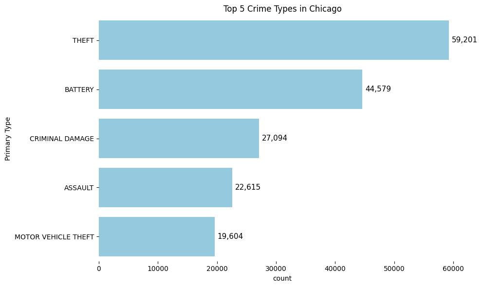

```python
topFiveCrimes = crimes['Primary Type'].value_counts().head(5).index

topCrimes = crimes[crimes['Primary Type'].isin(topFiveCrimes)]

plt.figure(figsize=(10, 6))
graph = sns.countplot(
    y='Primary Type',
    data=topCrimes,
    order=topFiveCrimes,
    color='skyblue'
)

for x in graph.patches:
    count = int(x.get_width())
    graph.text(count + 500,
            x.get_y() + x.get_height() / 2,
            f'{count:,}',
            va='center', fontsize=11)

plt.title("Top 5 Crime Types in Chicago")
sns.despine(left=True, bottom=True)
plt.tight_layout()
plt.show()
```

#### INSIGHTS #1

The top 5 most common crime types in Chicago are Theft, Battery, Criminal Damage, Assault and Motor Vehicle Theft

#### INSIGHTS #2

**Theft** is the most common crime in Chicago, with 59,201 recorded cases, far higher than any other crime type.

#### INSIGHTS #3

**Battery** ranks second with 44,579 cases, which is also a significant problem compared to other crimes.

#### INSIGHTS #4

**Criminal damage** (27,094 cases), while still common, occurs much less frequently than theft and battery.

#### INSIGHTS #5

**Assault (22,615 cases) and motor vehicle theft (19,604 cases)** are the least frequent among the top five, but they still represent a large number of incidents.

#### 2. What is the distribution of crimes by month?

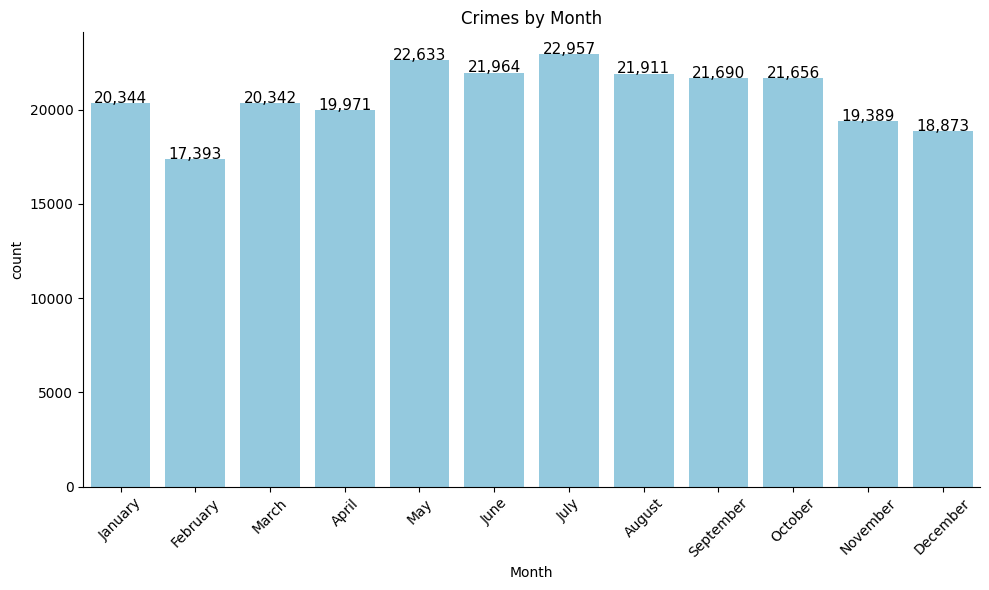

```python
monthNames = list(calendar.month_name)[1:]

plt.figure(figsize=(10, 6))
graph = sns.countplot(
    x='Month',
    data=crimes,
    order=range(1, 13),
    color='skyblue'
)

for x in graph.patches:
    height = x.get_height()
    graph.text(
        x.get_x() + x.get_width() / 2,
        height + 10,
        f'{int(height):,}',
        ha='center',
        fontsize=11
    )

plt.xticks(ticks=range(12), labels=monthNames, rotation=45)
plt.title("Crimes by Month")
sns.despine()
plt.tight_layout()
plt.show()
```

#### INSIGHTS #6

**July** has the highest number of crimes (22,957 cases), showing that crime peaks in the summer.

#### INSIGHTS #7

**February** records the lowest number of crimes (17,393 cases), which may be influenced by the shorter month and colder weather.

#### INSIGHTS #8

From **May to October**, crime levels are consistently high (all above 21,000), suggesting that warmer months generally see more crime.

#### INSIGHTS #9

The overall trend suggests a seasonal pattern, with crime rising in spring and peaking in summer, then declining towards winter.

#### 3. HeatMap of overall crime density in Chicago

```python
hm = folium.Map(location=[41.8781, -87.6298], zoom_start=11)
HeatMap(crimes[['Latitude','Longitude']].dropna()).add_to(hm)
hm
```

Make this Notebook Trusted to load map: File -> Trust Notebook

[interactive chart not shown]

#### INSIGHTS #10

The heatmap shows the densest red zones in the central and southern parts of the city, indicating these are major crime hotspots.

#### INSIGHTS #11

Crimes are more concentrated within city boundaries. The surrounding suburban areas show very little to no red zones, suggesting significantly lower crime levels compared to inner Chicago.

#### INSIGHTS #12

Southern neighborhoods closer to Hammond and near the city border also display high density, pointing to persistent crime activity in those areas.

#### 4. What are the most common FBI codes?

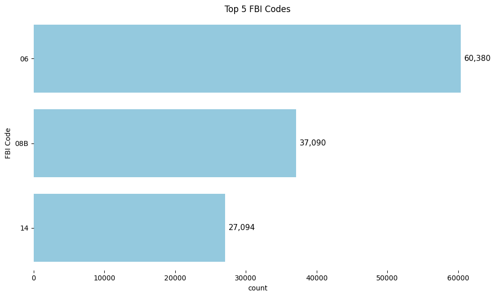

```python
topThreeCode = crimes['FBI Code'].value_counts().head(3).index

topCode = crimes[crimes['FBI Code'].isin(topThreeCode)]

plt.figure(figsize=(10, 6))
graph = sns.countplot(
    y='FBI Code',
    data=topCode,
    order=topThreeCode,
    color='skyblue'
)

# Add value labels on bars
for x in graph.patches:
    count = int(x.get_width())
    graph.text(
        count + 500,
        x.get_y() + x.get_height() / 2,
        f'{count:,}',
        va='center',
        fontsize=11
    )

plt.title("Top 5 FBI Codes")
sns.despine(left=True, bottom=True)
plt.tight_layout()
plt.show()
```

#### INSIGHTS #13

The most common FBI codes in the dataset are 06 (60,380 cases), 08B (37,090 cases), and 14 (27,094 cases)

#### INSIGHTS #14

**FBI Code 06** is the most common, with 60,380 cases, making it the dominant category in this dataset.

#### INSIGHTS #15

These top three codes together make up a large share of the total crimes, suggesting that crime in Chicago is concentrated within a few major FBI categories.

#### 5. How many arrests vs non-arrests?

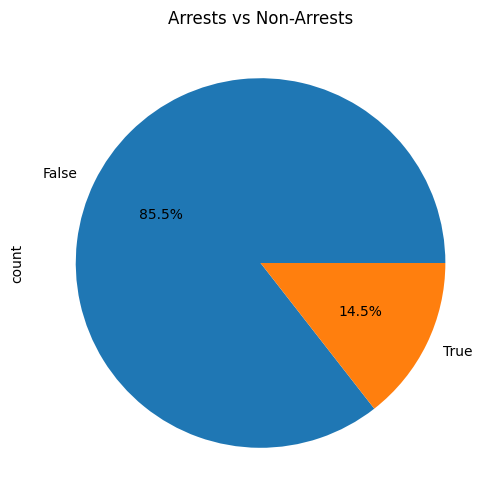

```python
plt.figure(figsize=(6,6))
crimes['Arrest'].value_counts().plot(kind='pie', autopct='%1.1f%%')
plt.title("Arrests vs Non-Arrests")
plt.show()
```

#### INSIGHTS #16

Most crimes do not result in an arrest about 85.5% of cases are non-arrests, meaning the majority of incidents remain unsolved or offenders are not apprehended.

#### INSIGHTS #17

Only 14.5% of crimes result in arrests, which shows a relatively low arrest rate compared to the total number of crimes reported.

#### 6. How many Domestic vs Non-Domestic Crimes?

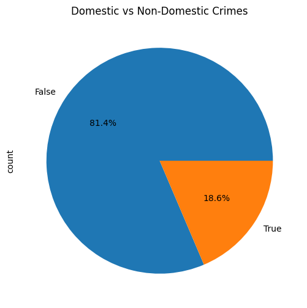

```python
plt.figure(figsize=(6,6))
crimes['Domestic'].value_counts().plot(kind='pie', autopct='%1.1f%%')
plt.title("Domestic vs Non-Domestic Crimes")
plt.show()
```

#### INSIGHTS #18

Non-domestic crimes make up the majority about 81.4% of all crimes, meaning most incidents occur outside the household setting.

#### INSIGHTS #19

Domestic crimes account for 18.6%, which is still a significant portion, showing that nearly 1 in 5 reported crimes happen in domestic situations.

## BIVARIATE ANALYSIS

#### 7. Crime counts by district and year

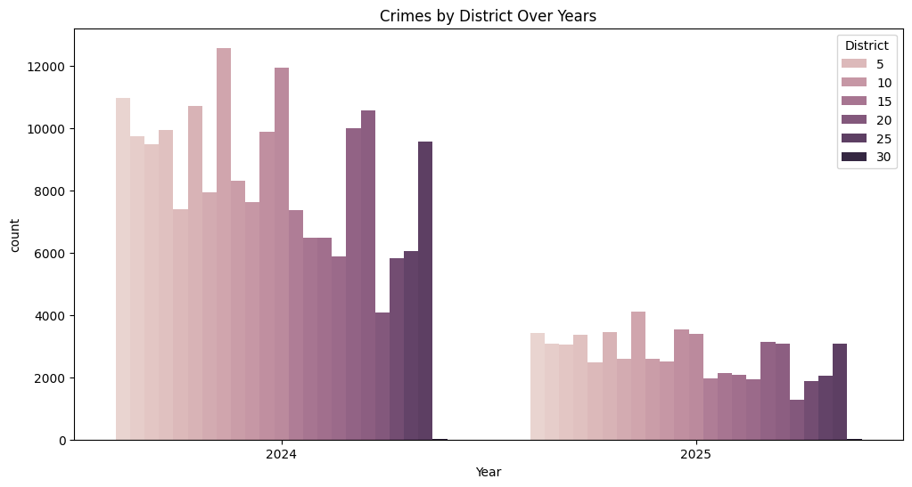

```python
plt.figure(figsize=(12,6))
sns.countplot(x='Year', hue='District', data=crimes)
plt.title("Crimes by District Over Years")
plt.show()
```

#### INSIGHTS #20

Crime levels were much higher in 2024 compared to 2025 across all districts, the counts dropped sharply in 2025.

#### INSIGHTS #22

The steep drop between 2024 and 2025 may suggest changes in reporting, policing strategies, or actual reduction in crime rates.

#### 8. Day vs Hour (extracted from Date)

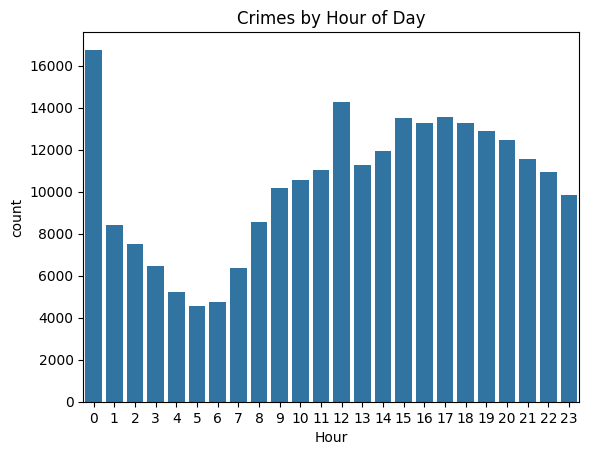

```python
crimes['Hour'] = pd.to_datetime(crimes['Date']).dt.hour
sns.countplot(x='Hour', data=crimes)
plt.title("Crimes by Hour of Day")
plt.show()
```

#### INSIGHTS #23

Crimes are most frequent around midnight and in the afternoon hours, while they are least common in the early morning (4–5 AM). This suggests that crimes are more likely during late-night activities and busy daytime hours.

#### 9. HeatMap of crimes during night hours (10pm–5am)

```python
night = crimes[(crimes['Hour']>=22) | (crimes['Hour']<=5)]
hmNight = folium.Map(location=[41.8781, -87.6298], zoom_start=11)
HeatMap(night[['Latitude','Longitude']].dropna()).add_to(hmNight)
hmNight
```

Make this Notebook Trusted to load map: File -> Trust Notebook

[interactive chart not shown]

#### INSIGHTS #24

Night crimes (10 PM–5 AM) are heavily concentrated in central and urban Chicago, especially near the downtown and along the lakefront, while suburban areas experience significantly fewer cases.

#### 10. Relationship between community area and crime frequency

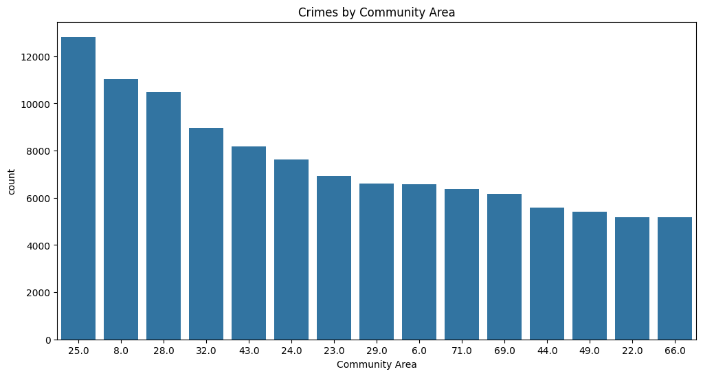

```python
plt.figure(figsize=(12,6))
sns.countplot(x='Community Area', data=crimes, order=crimes['Community Area'].value_counts().index[:15])
plt.title("Crimes by Community Area")
plt.show()
```

#### INSIGHTS #25

The top 15 community areas dominate crime cases. Each records at least 5,000+ incidents, suggesting that crimes are heavily concentrated in certain areas rather than evenly spread across the city.

#### INSIGHTS #26

A few community areas (like 25, 8, and 28) experience disproportionately higher crime rates compared to others, highlighting key hotspots for focused law enforcement and community safety efforts.

#### 11. Distribution of crimes across wards

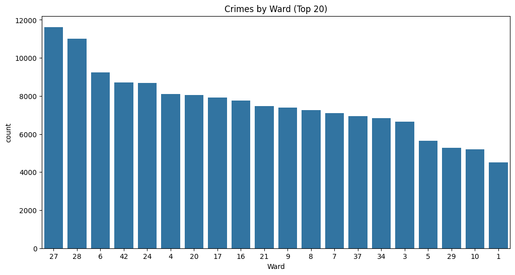

```python
plt.figure(figsize=(12,6))
sns.countplot(x='Ward', data=crimes, order=crimes['Ward'].value_counts().index[:20])
plt.title("Crimes by Ward (Top 20)")
plt.show()
```

#### INSIGHTS #27

Crimes are unevenly distributed across wards, while the top few wards (27, 28, 6, 42, 24) show very high crime volumes, there is a gradual decline as we move down the ranking, with Ward 1 having less than half the count of Ward 27.

#### INSIGHTS #28

There is no clear linear pattern across ward numbers. This suggests crime levels are not dependent on ward numbering but likely influenced by socio-economic, demographic, or geographic factors.

#### INSIGHTS #29

The distribution is highly uneven, with a few wards (notably 27 and 28) showing disproportionately high crime rates compared to others. This suggests that crime in the city is concentrated in specific hotspots rather than being evenly spread across all wards.

#### 12. HeatMap of crimes that resulted in arrest

```python
missKoNaSiGela = folium.Map(location=[41.8781, -87.6298], zoom_start=11)
HeatMap(crimes[crimes['Arrest']==True][['Latitude','Longitude']].dropna()).add_to(missKoNaSiGela)
missKoNaSiGela
```

Make this Notebook Trusted to load map: File -> Trust Notebook

[interactive chart not shown]

#### INSIGHTS #30

The heatmap reveals that arrests are heavily concentrated in Chicago’s central, southern, and lakeside areas, suggesting these regions have both higher crime activity and stronger law enforcement responses. In contrast, arrests are much less common in the western suburban areas, pointing to either fewer crimes or less policing intensity there.

## MULTIVARIATE ANALYSIS

#### 13. Yearly crime trend by weekday and arrest

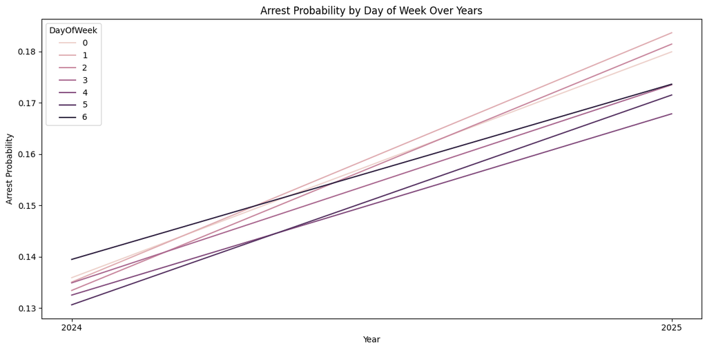

```python
plt.figure(figsize=(12, 6))

sns.lineplot(
    x='Year',
    y='Arrest',
    hue='DayOfWeek',
    data=crimes,
    estimator=np.mean,
    errorbar=None
)

plt.title("Arrest Probability by Day of Week Over Years")
plt.xlabel("Year")
plt.ylabel("Arrest Probability")

plt.xticks(sorted(crimes['Year'].unique()))
plt.tight_layout()
plt.show()
```

#### INSIGHTS #31

Sunday and Monday consistently show higher arrest probabilities compared to others such as Friday and Saturday. This suggests that the day of the week influences policing patterns or crime reporting/arrest likelihood.

#### INSIGHTS #32

The analysis reveals that arrest probabilities have increased steadily across all days of the week from 2024 to 2025, with certain days (especially earlier in the week) having consistently higher arrest rates. This suggests that law enforcement effectiveness is improving over time, though variations by weekday indicate that crime patterns and arrest likelihood are not uniform throughout the week.

#### 14. HeatMap of top 5 crimes in Chicago

```python
hmCrimes = crimes[crimes['Primary Type'].isin(topFiveCrimes)]
missNaMissKoNaSiGela = folium.Map(location=[41.8781, -87.6298], zoom_start=11)
HeatMap(hmCrimes[['Latitude','Longitude']].dropna()).add_to(missNaMissKoNaSiGela)
missNaMissKoNaSiGela
```

Make this Notebook Trusted to load map: File -> Trust Notebook

[interactive chart not shown]

#### INSIGHTS #33

The heatmap shows that the top five crime types in Chicago are not evenly spread but are instead concentrated in central, southern, and lakeshore regions. These areas represent high-density urban and commercial hubs, making them hotspots for criminal activity, while suburban and outer regions remain relatively less affected.

#### Multivariate correlation HeatMap

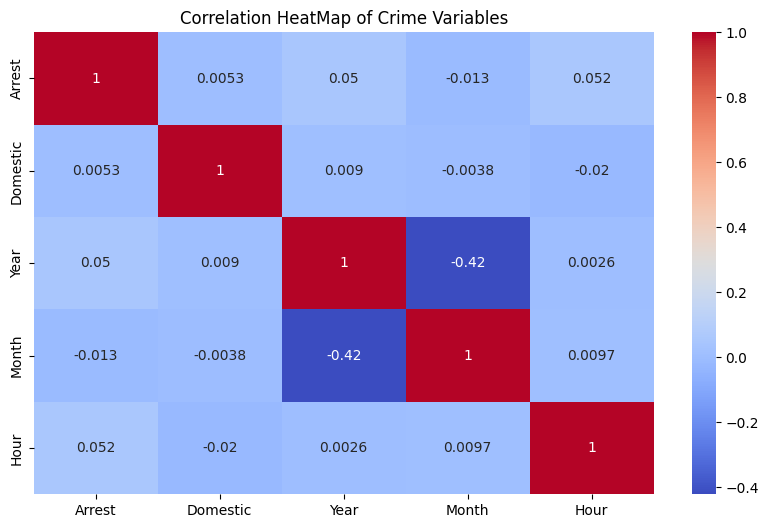

```python
plt.figure(figsize=(10,6))
sns.heatmap(crimes[['Arrest','Domestic','Year','Month','Hour']].corr(), annot=True, cmap="coolwarm")
plt.title("Correlation HeatMap of Crime Variables")
plt.show()
```

#### INSIGHTS #34

Year vs. Month has the strongest negative correlation (-0.42). This makes sense because "Month" repeats every year while "Year" keeps increasing, leading to an inverse relationship in the dataset encoding rather than a real-world crime trend.

#### INSIGHTS #35

Arrest vs. Year has a slight positive correlation (0.05). Indicating that in more recent years, there might be a trend of slightly higher arrest rates, consistent with earlier trends you saw in the line plot.

#### INSIGHTS #36

Arrest vs. Hour shows a slight positive correlation (0.052). This suggests that the time of day has some small influence on whether an arrest is made (possibly due to higher police activity during certain hours).

#### INSIGHTS #37

Weak correlations overall, most variables show correlations very close to zero, meaning that factors like arrest, domestic crimes, year, month, and hour are largely independent of each other in this dataset.

```python
list(crimes.columns)
```

```
['ID',
 'Case Number',
 'Date',
 'Block',
 'IUCR',
 'Primary Type',
 'Description',
 'Location Description',
 'Arrest',
 'Domestic',
 'Beat',
 'District',
 'Ward',
 'Community Area',
 'FBI Code',
 'X Coordinate',
 'Y Coordinate',
 'Year',
 'Updated On',
 'Latitude',
 'Longitude',
 'Location',
 'Month',
 'Day',
 'DayOfWeek',
 'Hour']
```

arigato gozaimasu